# Seminar 1

Eric

18 1 2021

#Velkommen til første seminar!

[figure not shown]

Gjennom 6 seminarganger skal vi nå gå igjennom alt fra hva R er og hvordan det fungerer, til å kjøre våre helt egne regresjonsanalyser og holde på med *egen statistikk.* Jeg gleder meg! Før hvert seminar kommeg jeg til å legge ut et dokument som dette. Dette har jeg faktisk laget i R! Her vil dere se at jeg har noe tekst (og memes, dere må like memes), og noe kode.

```r
#Kode vil dere se har en egen grå bakgrunn. Alt som er skrevet her kan dere kopiere inn på deres egen pc, og
#kjøre for å se hva som skjer. Når jeg har # foran betyr det at jeg skriver en kommentar. Dette kan vi gjøre i
#scriptene våre for å forklare hva som skjer, uten at R prøver å kjøre det som vanlig kode og derfor gir en
#feilmelding.
#Hvis jeg kjører kode her, vil dere se resultatene som vanlig tekst under. Vi kan jo gjøre et lite forsøk
# med noe enkel matte!
100/2+4
```

```
## [1] 54
```

#R, RStudio, og Syntax-feil

[figure not shown]

Før seminaret har dere lastet ned R, og RStudio. R er selve programeringsspråket vi skriver i, og som gjør at vi kan skrive kode. Når vi laster ned R laster vi egentlig ned et program som gjør at datamaskingen vår kan forstå det vi skriver, og gjør det vi ønsker at den gjør. Selve R-skriptet, eller koden om en vil, kunne vi egentlig skrevet i word, eller notisblokk. RStudio, programmet vi kommer til å bruke, er det som kalles et “Integrated development environment” (IDE), og brukes for å gjøre det lettere å skrive skriptet. Her har vi f.eks. enkel tilgang til hjelpefiler, den markerer hva forskjellig kode er ved hjelp av farger, og presenterer resultatene på en (vanligvis) lettleselig måte.

[figure not shown]

```r
#Ofte når vi bruker R er vi usikre på hvordan forskjellige funksjoner fungerer.
#Da kan det være nyttig å lese hjelpefilene som forteller hva en funksjon gjør, og hvordan
#en skal bruke den. For å gjøre dette skriver du et spørsmålstegn før navnet på funksjonen.
#La oss prøve dette med "mean()" funksjonen, som logisk nok finner gjennomsnitt:
?mean
```

```
## starting httpd help server ... done
```

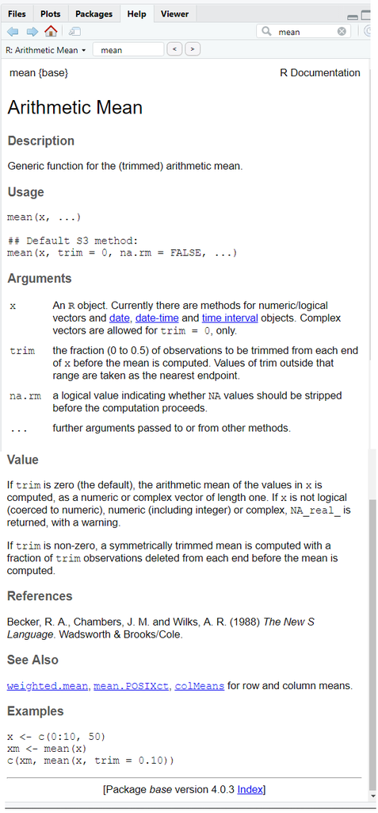

I hjelpefilen kan vi se at vi får en del informasjon om funksjonen, men la oss først tenkte litt på hva en funksjon er. I R jobber vi som oftest med forskjellige typer objekter. Vi skal straks komme tilbake til hva objekter er, men la oss i første omgang tenke på en rekke tall. Si vi har tallene fra 1-10. Hovedpoenget med R er at når vi har slike data, ønsker vi å hente ut noe *informasjon* fra dem. Dette kan f.eks. være gjennomsnitt, standardavvvik ++. En funksjon er det vi bruker i R for å gjøre noe med dataene, f.eks. å hente ut denne informasjonen. Alle funksjoner har til felles at de tar noe data, f.eks. tall, og skaper et resultat. I tilegg har noen argumenter som gjør at vi kan endre noe på hvordan funksjonen lager resultatet. Leser vi hjelpefilen til “mean” ser vi at den øverst gir en beskrivelse, hvor det står at den returnerer gjennomsnittet. Under der kommer argumentene den godtar, et objekt (x) som inneholder tall, logiske verdier (kommer tilbake til hva det er), ett argument for å trimme dataene, altså fjerne noe, og na.rm argumentet. Det siste skal vi også komme tilbake til. Under Value får vi en beskrivelse av hva som er returnert, før til slutt et eksempel av hvordan den brukes i bunn.

Hjelpefilene er en flott måte å finne ut hva en funksjon gjør, og hvordan vi kan bruke den. Samtidig kan den ofte være litt kronglete å lese, men da hjelper det ofte å se på eksemplene som alltid er i bunn av teksten. Skulle det fortsatt være vanskelig er det viktig å huske at det finnes et stort miljø rundt R, og ofte er det mange som har opplevd samme problem som deg! Litt kjapp googling, og et søk på https://stackoverflow.com/ vil fort gi gode svar!

[figure not shown]

##Syntax-feil

[figure not shown]

Når vi går igjennom kode vil vi fort få en del feil. Det er helt vanlig, og noe som er helt uungåelig! Dere vil nok fort merke at jeg gjør en hel del feil når jeg skal vise dere i seminaret. En type feil kan likevell være godt å merke seg med en gang, mest fordi jeg gjør den hver gang jeg skal skrive noe kode. “Syntax-feil” er skrivefeil vi gjør når vi skriver kode. F.eks. kan det være å skrive men() istedenfor mean(), glemme å lukke en parantes sånn at vi skriver mean( . Noe av det fine med RStudio er at den markere sånne feil for oss!

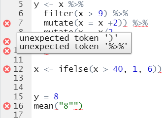

Her har jeg skrevet noe tullekode for å vise ossen dette funker. Som dere kan se på siden får jeg flere røde kryss ved siden av linjenummerene. Dette er steder hvor RStudio mener jeg har gjort feil, og holder jeg musen over dem får jeg opp hva som er feilen. “Unexpected token ‘)’” betyr at RStudio mener det er en parantes der som ikke skulle vært der. I tilegg er det røde streker under de delene av koden som RStudio mener er feil. Jeg vil hevde, hvertfall etter min egen erfaring, at 90 % av feilene vi gjør i R er enkle skrivefeil/syntax-feil som dette. Derfor er det veldig nyttig at RStudio viser det på denne måten! Uansett, vi er ikke her for å snakke om hypotetiske feil.